# PROJECT PROPOSAL

VAIBHAV AMITBHAI PATEL

12-08-2021

| **SECTION 1 - INTRODUCTION** |
| --- |

*According to the World Health Organization (WHO) stroke is the 2nd leading cause of death globally, responsible for approximately 11% of total deaths.*

*This dataset is used to predict whether a patient is likely to get stroke based on the input parameters like gender, age, various diseases, and smoking status.*

*Each row in the data provides relavant information about the patient.*

*The variables in the given Dataset with its discription are as follows:*

| **ATTRIBUTE INFORMATION** |
| --- |

**1) id:** unique identifier

**2) gender:** “Male”, “Female” or “Other”

**3) age:** age of the patient

**4) hypertension:** 0 if the patient doesn’t have hypertension, 1 if the patient has hypertension

**5) heart_disease:** 0 if the patient doesn’t have any heart diseases, 1 if the patient has a heart disease

**6) ever_married:** “No” or “Yes”

**7) work_type:** “children”, “Govt_jov”, “Never_worked”, “Private” or “Self-employed”

**8) Residence_type:** “Rural” or “Urban”

**9) avg_glucose_level:** average glucose level in blood

**10) bmi:** body mass index

**11) smoking_status:** “formerly smoked”, “never smoked”, “smokes” or “Unknown”

**12) stroke:** 1 if the patient had a stroke or 0 if not

*Note: “Unknown” in smoking_status means that the information is unavailable for this patient*

**SOURCE:-** https://www.kaggle.com/fedesoriano/stroke-prediction-dataset

| *There are some general questions related to this data set.* |
| --- |

**Question 1: What is the highest value of average level of glucose in health care dataset stroke?**

**Question 2: Create a plot of single categorical variable.?**

**Question 3: Create a plot of heart disease & Ever married?**

**Question 4: Create a appropriate plot to visualize the distribution of numeric variable.?**

**Question 5: Create a appropriate plot to visualize the proportion of categorical variable.?**

**Question 6: Create a appropriate plot to visualize the relationship between the two numeric variables.?**

**Question 7: Create a appropriate plot to visualize the relationship between the numeric and categorical variables.?**

**Question 8: Choose and calculate tendency of any numerical variable by using appropriate statistical method.?**

**Question 9: Choose an appropriate method to calculate spread of any variable.?**

**Question 10: How to find unique values of any variable.?**

| **SECTION 2 - DATA ANALYSIS PLAN** |
| --- |

**Loading Tidyverse.**

| *DATA ANALYSIS PLAN* |
| --- |

*The Explanatory variables are : Gender, Age, BMI, Ever Married*

*I am going to compare data on the basis of several variables available in this data set.*

| **PRELIMINARY VISUALIZATION AND ANALYSIS** |
| --- |

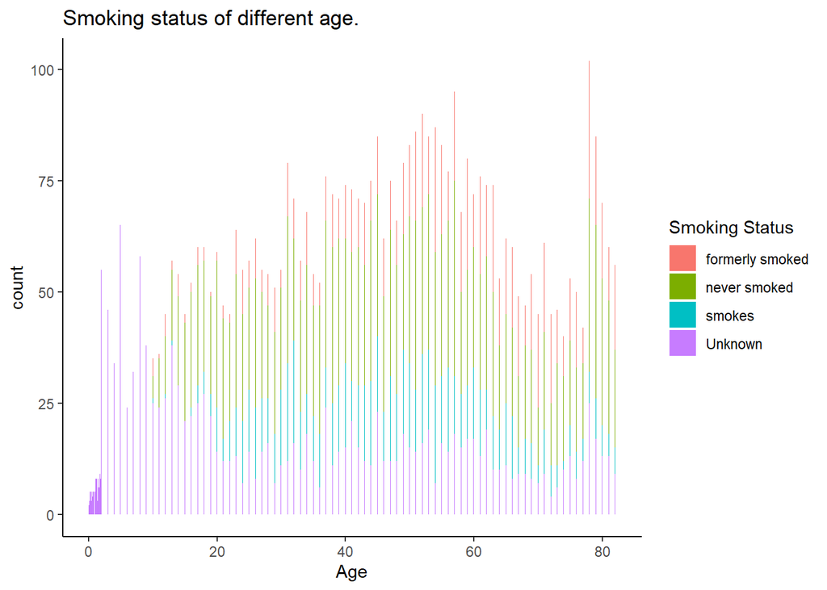

*This Analysis is very helpful because, this data set is based on stroke and strokedata is only considered useful if that particular variable can be find . Moreover, this analysis shows the smoking status of different age people and it also provides the common thoughts of data but, at the specific time it also helps in the understanding of other various objects too. Rather than this, there are other elements too which is vital to illustrate the why stroke can happen*

*The statistical methods which can be useful are Standard Deviation, Uniqueness, as well as Mean of data. Furthermore, standard deviation is the perfect choice for measuring spread of the any given data. Additionally, unique is used to search the uniqueness of any variable while, mean is the most daily used method to measure tendency. So, using mean here is useful because, the mean uses the whole data set values and provides an average value of each variable.*

| *SUMMARY OF THE DATA SET* |
| --- |

**Head of the data set.**

|  | id | gender | age | hypertension | heart_disease | ever_married | work_type | Residence_type | avg_glucose_level | bmi | smoking_status | stroke |
| --- | --- | --- | --- | --- | --- | --- | --- | --- | --- | --- | --- | --- |
| 1 | 9046 | Male | 67 | 0 | 1 | Yes | Private | Urban | 228.69 | 36.6 | formerly smoked | 1 |
| 2 | 51676 | Female | 61 | 0 | 0 | Yes | Self-employed | Rural | 202.21 | N/A | never smoked | 1 |
| 3 | 31112 | Male | 80 | 0 | 1 | Yes | Private | Rural | 105.92 | 32.5 | never smoked | 1 |
| 4 | 60182 | Female | 49 | 0 | 0 | Yes | Private | Urban | 171.23 | 34.4 | smokes | 1 |
| 5 | 1665 | Female | 79 | 1 | 0 | Yes | Self-employed | Rural | 174.12 | 24 | never smoked | 1 |
| 6 | 56669 | Male | 81 | 0 | 0 | Yes | Private | Urban | 186.21 | 29 | formerly smoked | 1 |

**Tail of the data set.**

|  | id | gender | age | hypertension | heart_disease | ever_married | work_type | Residence_type | avg_glucose_level | bmi | smoking_status | stroke |
| --- | --- | --- | --- | --- | --- | --- | --- | --- | --- | --- | --- | --- |
| 5105 | 14180 | Female | 13 | 0 | 0 | No | children | Rural | 103.08 | 18.6 | Unknown | 0 |
| 5106 | 18234 | Female | 80 | 1 | 0 | Yes | Private | Urban | 83.75 | N/A | never smoked | 0 |
| 5107 | 44873 | Female | 81 | 0 | 0 | Yes | Self-employed | Urban | 125.20 | 40 | never smoked | 0 |
| 5108 | 19723 | Female | 35 | 0 | 0 | Yes | Self-employed | Rural | 82.99 | 30.6 | never smoked | 0 |
| 5109 | 37544 | Male | 51 | 0 | 0 | Yes | Private | Rural | 166.29 | 25.6 | formerly smoked | 0 |
| 5110 | 44679 | Female | 44 | 0 | 0 | Yes | Govt_job | Urban | 85.28 | 26.2 | Unknown | 0 |

**Summary of the data set.**

```
##        id           gender               age         hypertension
##  Min.   :   67   Length:5110        Min.   : 0.08   Min.   :0.00000
##  1st Qu.:17741   Class :character   1st Qu.:25.00   1st Qu.:0.00000
##  Median :36932   Mode  :character   Median :45.00   Median :0.00000
##  Mean   :36518                      Mean   :43.23   Mean   :0.09746
##  3rd Qu.:54682                      3rd Qu.:61.00   3rd Qu.:0.00000
##  Max.   :72940                      Max.   :82.00   Max.   :1.00000
##  heart_disease     ever_married        work_type         Residence_type
##  Min.   :0.00000   Length:5110        Length:5110        Length:5110
##  1st Qu.:0.00000   Class :character   Class :character   Class :character
##  Median :0.00000   Mode  :character   Mode  :character   Mode  :character
##  Mean   :0.05401
##  3rd Qu.:0.00000
##  Max.   :1.00000
##  avg_glucose_level     bmi            smoking_status         stroke
##  Min.   : 55.12    Length:5110        Length:5110        Min.   :0.00000
##  1st Qu.: 77.25    Class :character   Class :character   1st Qu.:0.00000
##  Median : 91.89    Mode  :character   Mode  :character   Median :0.00000
##  Mean   :106.15                                          Mean   :0.04873
##  3rd Qu.:114.09                                          3rd Qu.:0.00000
##  Max.   :271.74                                          Max.   :1.00000
```

| **SECTION 3 - DATA SELECTED** |
| --- |

**Having Glimpse of data set.**

```
## Rows: 5,110
## Columns: 12
## $ id                <int> 9046, 51676, 31112, 60182, 1665, 56669, 53882, 10434~
## $ gender            <chr> "Male", "Female", "Male", "Female", "Female", "Male"~
## $ age               <dbl> 67, 61, 80, 49, 79, 81, 74, 69, 59, 78, 81, 61, 54, ~
## $ hypertension      <int> 0, 0, 0, 0, 1, 0, 1, 0, 0, 0, 1, 0, 0, 0, 0, 1, 0, 1~
## $ heart_disease     <int> 1, 0, 1, 0, 0, 0, 1, 0, 0, 0, 0, 1, 0, 1, 1, 0, 1, 0~
## $ ever_married      <chr> "Yes", "Yes", "Yes", "Yes", "Yes", "Yes", "Yes", "No~
## $ work_type         <chr> "Private", "Self-employed", "Private", "Private", "S~
## $ Residence_type    <chr> "Urban", "Rural", "Rural", "Urban", "Rural", "Urban"~
## $ avg_glucose_level <dbl> 228.69, 202.21, 105.92, 171.23, 174.12, 186.21, 70.0~
## $ bmi               <chr> "36.6", "N/A", "32.5", "34.4", "24", "29", "27.4", "~
## $ smoking_status    <chr> "formerly smoked", "never smoked", "never smoked", "~
## $ stroke            <int> 1, 1, 1, 1, 1, 1, 1, 1, 1, 1, 1, 1, 1, 1, 1, 1, 1, 1~
```